# CSP571_Project_Experimentation for Pennsylvania conventional home loans for 2014

2/17/2020

## Global setup like working directory, data directory etc should happen here.

```r
# Please change the working directory as needed.
working_dir <- "D:/illinois/csp571/csp-571-02-final-project"
setwd(working_dir)

data_dir <- "D:/data/HMDA"
```

## Install required packages.

```r
library(mice)
```

## Load data file.

```r
hmda_data_pa <- fread("hmda_2014_pa_all-records_labels.csv")
```

```
|--------------------------------------------------|
|==================================================|
```

```r
summary(hmda_data_pa_df)
```

```
   as_of_year   respondent_id      agency_name        agency_abbr         agency_code
 Min.   :2014   Length:322785      Length:322785      Length:322785      Min.   :1.000
 1st Qu.:2014   Class :character   Class :character   Class :character   1st Qu.:5.000
 Median :2014   Mode  :character   Mode  :character   Mode  :character   Median :7.000
 Mean   :2014                                                            Mean   :6.348
 3rd Qu.:2014                                                            3rd Qu.:9.000
 Max.   :2014                                                            Max.   :9.000

 loan_type_name       loan_type property_type_name property_type   loan_purpose_name
 Length:322785      Min.   :1   Length:322785      Min.   :1.000   Length:322785
 Class :character   1st Qu.:1   Class :character   1st Qu.:1.000   Class :character
 Mode  :character   Median :1   Mode  :character   Median :1.000   Mode  :character
                    Mean   :1                      Mean   :1.032
                    3rd Qu.:1                      3rd Qu.:1.000
                    Max.   :1                      Max.   :3.000

  loan_purpose   owner_occupancy_name owner_occupancy loan_amount_000s  preapproval_name
 Min.   :1.000   Length:322785        Min.   :1.00    Min.   :    1.0   Length:322785
 1st Qu.:1.000   Class :character     1st Qu.:1.00    1st Qu.:   60.0   Class :character
 Median :2.000   Mode  :character     Median :1.00    Median :  120.0   Mode  :character
 Mean   :2.075                        Mean   :1.12    Mean   :  168.2
 3rd Qu.:3.000                        3rd Qu.:1.00    3rd Qu.:  206.0
 Max.   :3.000                        Max.   :3.00    Max.   :99999.0

  preapproval    action_taken_name   action_taken    msamd_name            msamd
 Min.   :1.000   Length:322785      Min.   :1.000   Length:322785      Min.   :10900
 1st Qu.:3.000   Class :character   1st Qu.:1.000   Class :character   1st Qu.:30140
 Median :3.000   Mode  :character   Median :1.000   Mode  :character   Median :37964
 Mean   :2.879                      Mean   :2.268                      Mean   :33728
 3rd Qu.:3.000                      3rd Qu.:3.000                      3rd Qu.:38300
 Max.   :3.000                      Max.   :7.000                      Max.   :49660
                                                                       NA's   :28898
  state_name         state_abbr          state_code county_name         county_code
 Length:322785      Length:322785      Min.   :42   Length:322785      Min.   :  1.00
 Class :character   Class :character   1st Qu.:42   Class :character   1st Qu.: 19.00
 Mode  :character   Mode  :character   Median :42   Mode  :character   Median : 65.00
                                       Mean   :42                      Mean   : 60.87
                                       3rd Qu.:42                      3rd Qu.: 95.00
                                       Max.   :42                      Max.   :133.00
                                                                       NA's   :442
```

[output cut: 97 more lines]

```
 Min.   :52700            Min.   : 12.10        Min.   :   7
 1st Qu.:54200            1st Qu.: 89.09        1st Qu.: 953
 Median :65600            Median :106.05        Median :1357
 Mean   :68579            Mean   :111.97        Mean   :1399
 3rd Qu.:71500            3rd Qu.:127.01        3rd Qu.:1795
 Max.   :96300            Max.   :397.45        Max.   :3262
 NA's   :925              NA's   :991           NA's   :963
 number_of_1_to_4_family_units application_date_indicator
 Min.   :   8                  Min.   :0.0000
 1st Qu.:1340                  1st Qu.:0.0000
 Median :1758                  Median :0.0000
 Mean   :1823                  Mean   :0.1732
 3rd Qu.:2289                  3rd Qu.:0.0000
 Max.   :4173                  Max.   :2.0000
 NA's   :945
```

## Data analysis section 2. Print glimpse of dataset i.e a vertical preview of the dataset.

```r
dim(hmda_data_pa_df)
writeLines("Glimpse of hmda dataset for PA")
glimpse(hmda_data_pa_df)
```

[output not shown]

## Data analysis section 2. Print structure of dataset.

```r
str(hmda_data_pa_df)
```

[output not shown]

## Data Analysis Section 3. Check for missing values in the dataset

```r
sapply(hmda_data_pa_df, function(x) sum(is.na(x)))
```

```
                    as_of_year                  respondent_id
                             0                              0
                   agency_name                    agency_abbr
                             0                              0
                   agency_code                 loan_type_name
                             0                              0
                     loan_type             property_type_name
                             0                              0
                 property_type              loan_purpose_name
                             0                              0
                  loan_purpose           owner_occupancy_name
                             0                              0
               owner_occupancy               loan_amount_000s
                             0                              0
              preapproval_name                    preapproval
                             0                              0
             action_taken_name                   action_taken
                             0                              0
                    msamd_name                          msamd
                             0                          28898
                    state_name                     state_abbr
                             0                              0
                    state_code                    county_name
                             0                              0
                   county_code            census_tract_number
                           442                            925
      applicant_ethnicity_name            applicant_ethnicity
                             0                              0
   co_applicant_ethnicity_name         co_applicant_ethnicity
                             0                              0
         applicant_race_name_1               applicant_race_1
                             0                              0
         applicant_race_name_2               applicant_race_2
                             0                         321968
         applicant_race_name_3               applicant_race_3
                             0                         322717
         applicant_race_name_4               applicant_race_4
                             0                         322750
         applicant_race_name_5               applicant_race_5
                             0                         322753
```

[output cut: 23 more lines]

```
                        321434                         317302
             hoepa_status_name                   hoepa_status
                             0                              0
              lien_status_name                    lien_status
                             0                              0
              edit_status_name                    edit_status
                             0                         270997
               sequence_number                     population
                             0                            927
           minority_population       hud_median_family_income
                           935                            925
         tract_to_msamd_income number_of_owner_occupied_units
                           991                            963
 number_of_1_to_4_family_units     application_date_indicator
                           945                              0
```

## Look at values in the ethnicity and race columns

```r
hmda_data_pa_df %>% filter(applicant_ethnicity_name == "Hispanic or Latino") %>%
  group_by(applicant_race_name_1) %>%
           count() %>%
           ungroup() %>%
           replace(is.na(.), 0) %>%
           adorn_totals(c("col")) %>%
           arrange(-Total)
```

```
                                                             applicant_race_name_1    n Total
                                                                             White 6777  6777
 Information not provided by applicant in mail, Internet, or telephone application 1192  1192
                                                         Black or African American  447   447
                                         Native Hawaiian or Other Pacific Islander  205   205
                                                  American Indian or Alaska Native  204   204
                                                                             Asian   74    74
```

## Add a new column applicant_race_and_ethnicity and group all applicants

## with ethnicity as Hispanic or Latino as Hispanic or Latino in this column.

## For everyone else, this column gets values from the applicant_race_name_1

## Graph mortgage distribution by applicant race and ethinicity.

```r
mortgage_by_race_and_ethnicity = hmda_data_pa_df %>% group_by(applicant_race_and_ethnicity) %>%
  summarise(EthnicityCount = n()) %>%
  arrange(desc(EthnicityCount))

graph_by_enthicity(mortgage_by_race_and_ethnicity)
```

[output not shown]

# Graph which applicant races and ethnicities have the largest proportion of loans

# in various stages. These include origination status, denied status, etc.

```r
mortgage_status_by_race_and_ethnicity <- hmda_data_pa_df %>% group_by(action_taken_name, applicant_race_and_ethnicity) %>%
  summarise(ActionCount = n()) %>%
  arrange(desc(ActionCount))

mortgage_status_aggregated_by_race_and_ethnicity  = inner_join(mortgage_status_by_race_and_ethnicity, mortgage_by_race_and_ethnicity) %>% mutate(percentage = (ActionCount / EthnicityCount) * 100)

graph_application_race_proportion_of_loans(mortgage_status_aggregated_by_race_and_ethnicity)
```

[output not shown]

# Applicant income histograms.

```r
graph_applicant_income_histogram(hmda_origination_status_df, "Applicant income distribution for originated loans")
```

[output not shown]

# Graph median income for originated loans.

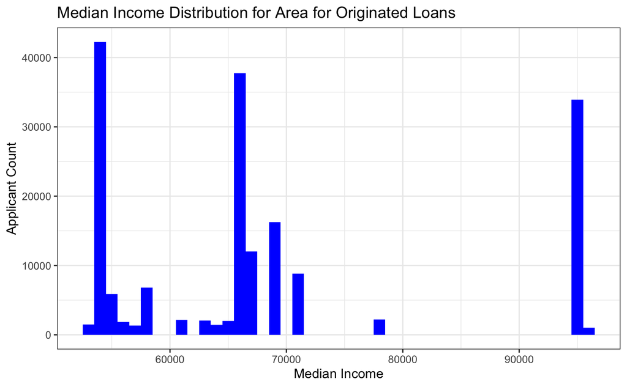

## Graph loan distribution by county.

```r
graph_distribution_by_county(mortgage_distribution_by_counties)
```

[output not shown]

## chart by applicant_race_1

```r
for (county_name in county_names) {

  hmda_data_county_df <- hmda_data_pa_df[hmda_data_pa_df$county_name == county_name, ]

  mortgage_by_race_county <- hmda_data_county_df %>% group_by(applicant_race_name_1) %>%
    summarise(RaceCount = n()) %>% arrange(desc(RaceCount))

  print(graph_mortgage_distribution_by_race1(mortgage_by_race_county))
}
```

[output not shown]

## Graph income distribution for Whites and African Americans per county for the

## top 4 counties above.

```r
for (county_name in county_names) {
  hmda_origination_status_df_by_county_white <- hmda_data_pa_df[hmda_data_pa_df$action_taken == "1" & hmda_data_pa_df$county_name == county_name & hmda_data_pa_df$applicant_race_name_1 == "White", ]
  print(graph_applicant_income_histogram(hmda_origination_status_df_by_county_white, "Income distribution for Whites"))

  hmda_origination_status_df_by_county_african_american <- hmda_data_pa_df[hmda_data_pa_df$action_taken == "1" & hmda_data_pa_df$county_name == county_name & hmda_data_pa_df$applicant_race_name_1 == "Black or African American", ]
  print(graph_applicant_income_histogram(hmda_origination_status_df_by_county_african_american, "Income distribution for African Americans"))
}
```

[output not shown]

## chart by applicant_race_and_ethnicity

```r
county_names <- c("Allegheny County", "Philadelphia County", "Montgomery County", "Bucks County")

for (county_name in county_names) {

  hmda_data_county_df <- hmda_data_pa_df[hmda_data_pa_df$county_name == county_name, ]

  mortgage_by_race_county <- hmda_data_county_df %>% group_by(applicant_race_and_ethnicity) %>%
    summarise(RaceCount = n()) %>% arrange(desc(RaceCount))

  print(graph_mortgage_distribution_by_race_and_ethnicity(mortgage_by_race_county))
}
```

[output not shown]

# Graph which communities have the largest proportion of loans in various stages.

# for the top 4 counties listed above.

# These include origination status, denied status, etc.

```r
for (county_name in county_names) {

  hmda_data_county_df <- hmda_data_pa_df[hmda_data_pa_df$county_name == county_name, ]

  mortgage_by_race1_county <- hmda_data_county_df %>% group_by(applicant_race_and_ethnicity) %>%
    summarise(RaceCount = n()) %>% arrange(desc(RaceCount))

  mortgage_status_by_race1_by_county <- hmda_data_county_df %>% group_by(action_taken_name, applicant_race_and_ethnicity) %>%
    summarise(ActionCount = n()) %>%
    arrange(desc(ActionCount))

  mortgage_status_aggregated_by_race1_by_county  = inner_join(mortgage_status_by_race1_by_county, mortgage_by_race1_county) %>% mutate(percentage = (ActionCount / RaceCount) * 100)

  print(graph_application_race_and_ethnicity_proportion_of_loans(mortgage_status_aggregated_by_race1_by_county))
}
```

[output not shown]

# Visualize missing variables and impute as needed.

```r
sapply(hmda_data_pa_df_imputed,function (x) sum(is.na(x)))
```

```
   applicant_race_and_ethnicity           applicant_income_000s co_applicant_race_and_ethnicity
                              0                               0                               0
               co_applicant_sex                     county_code                    hoepa_status
                              0                               0                               0
                    lien_status                           msamd                 owner_occupancy
                              0                               0                               0
                    preapproval                   property_type                  purchaser_type
                              0                               0                               0
               loan_amount_000s                     county_name                   applicant_sex
                              0                               0                               0
       hud_median_family_income           tract_to_msamd_income                     agency_code
                              0                               0                               0
            minority_population
                              0
```

## More analysis on the imputed dataset.

```r
gg_miss_upset(hmda_data_pa_df_imputed)
```

[output not shown]

# Additional analysis on the hmda dataset. correlation matrix, plots, etc.

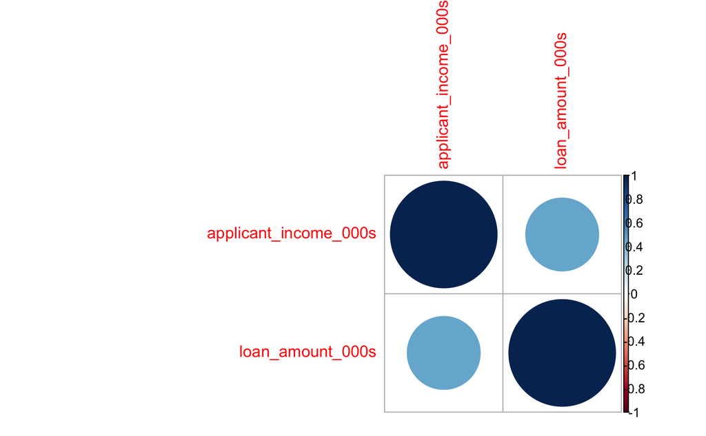

# Additional analysis on the hmda imputed dataset. correlation plots, etc.

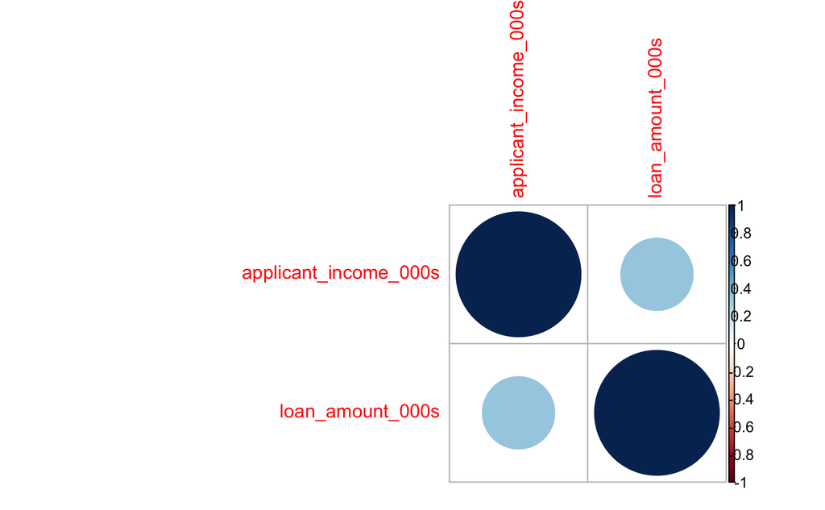

# Preparation for inital model. Selecting columns.

# Create dataframe based on selected column list from the source dataframe.

```r
hmda_data_pa_df_imputed_for_model <- data_frame_for_model(hmda_data_pa_df_imputed)
```

```
Note: Using an external vector in selections is ambiguous.
ℹ Use `all_of(initial_columns_for_model)` instead of `initial_columns_for_model` to silence this message.
ℹ See <https://tidyselect.r-lib.org/reference/faq-external-vector.html>.
```

```r
str(hmda_data_pa_df_imputed_for_model)
```

```
'data.frame':   322785 obs. of  24 variables:
 $ applicant_race_and_ethnicity   : Factor w/ 8 levels "American Indian or Alaska Native",..: 8 8 8 3 8 7 8 8 5 8 ...
 $ applicant_income_000s          : num  30 49 76 105 53 156 36 145 150 19 ...
 $ co_applicant_race_and_ethnicity: Factor w/ 9 levels "American Indian or Alaska Native",..: 7 7 7 7 7 8 7 9 5 7 ...
 $ co_applicant_sex               : Factor w/ 5 levels "1","2","3","4",..: 5 5 5 5 5 4 5 2 3 5 ...
 $ county_code                    : Factor w/ 67 levels "1","3","5","7",..: 37 67 36 9 48 9 24 15 54 22 ...
 $ hoepa_status                   : Factor w/ 2 levels "1","2": 2 2 2 2 2 2 2 2 2 2 ...
 $ lien_status                    : Factor w/ 4 levels "1","2","3","4": 1 1 1 1 1 4 1 1 1 1 ...
 $ msamd                          : num  37964 49620 29540 33874 10900 ...
 $ owner_occupancy                : Factor w/ 3 levels "1","2","3": 1 1 1 1 1 2 1 1 1 1 ...
 $ preapproval                    : Factor w/ 3 levels "1","2","3": 3 3 2 3 3 3 3 3 3 3 ...
 $ property_type                  : Factor w/ 3 levels "1","2","3": 1 1 1 1 1 1 1 1 1 1 ...
 $ purchaser_type                 : Factor w/ 9 levels "0","1","3","4",..: 1 3 1 1 1 2 1 1 1 2 ...
 $ loan_amount_000s               : int  81 132 158 236 53 150 108 265 196 67 ...
 $ county_name                    : Factor w/ 68 levels "","Adams County",..: 38 68 37 10 49 10 25 16 55 23 ...
 $ applicant_sex                  : Factor w/ 4 levels "1","2","3","4": 1 1 2 2 2 4 1 1 3 2 ...
 $ hud_median_family_income       : num  54100 68700 67200 95400 68800 95400 54100 95400 54100 71500 ...
 $ tract_to_msamd_income          : num  96.8 93.1 161.9 69.8 102.2 ...
 $ loan_to_income_ratio           : num  2.7 2.69 2.08 2.25 1 ...
 $ agency_code                    : Factor w/ 6 levels "1","2","3","5",..: 5 1 5 5 3 5 3 4 5 5 ...
 $ minority_population            : num  2.53 10.74 14.19 15.31 6.07 ...
 $ loan_granted                   : logi  FALSE TRUE FALSE FALSE TRUE TRUE ...
 $ co_applicant_present           : Factor w/ 2 levels "0","1": 1 1 1 1 1 1 1 2 1 1 ...
 $ log_loan_amount_000s           : num  4.39 4.88 5.06 5.46 3.97 ...
 $ log_applicant_income_000s      : num  3.4 3.89 4.33 4.65 3.97 ...
```

# Train test split. Stratified sampling

# Generate train/test split.

```r
unique(train$loan_granted)
```

```
[1] TRUE  FALSE
Levels: FALSE TRUE
```

# Analysis on the train and test split datasets.

```r
sum(test$applicant_race_and_ethnicity == "Black or African American")
```

```
[1] 3013
```

# Model 1 without loan to income ratio.

```r
writeLines("Anova for model is as below")
```

[output not shown]

```
Anova for model is as below
```

# Model plots

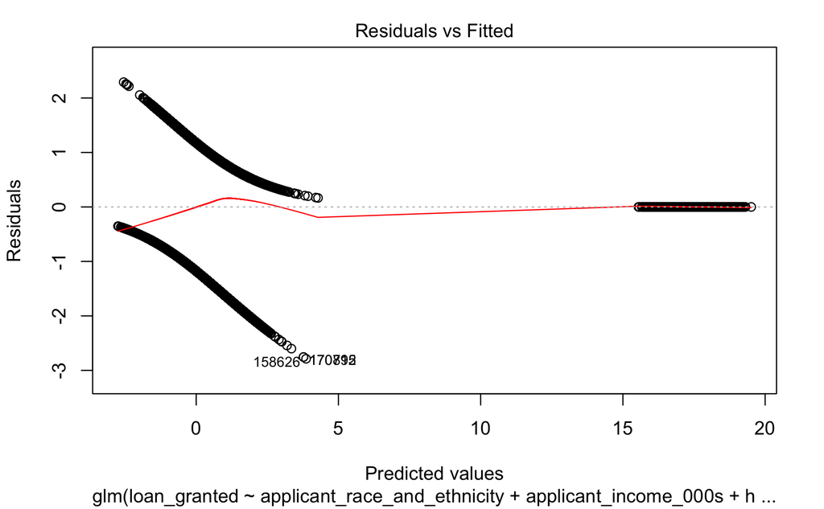

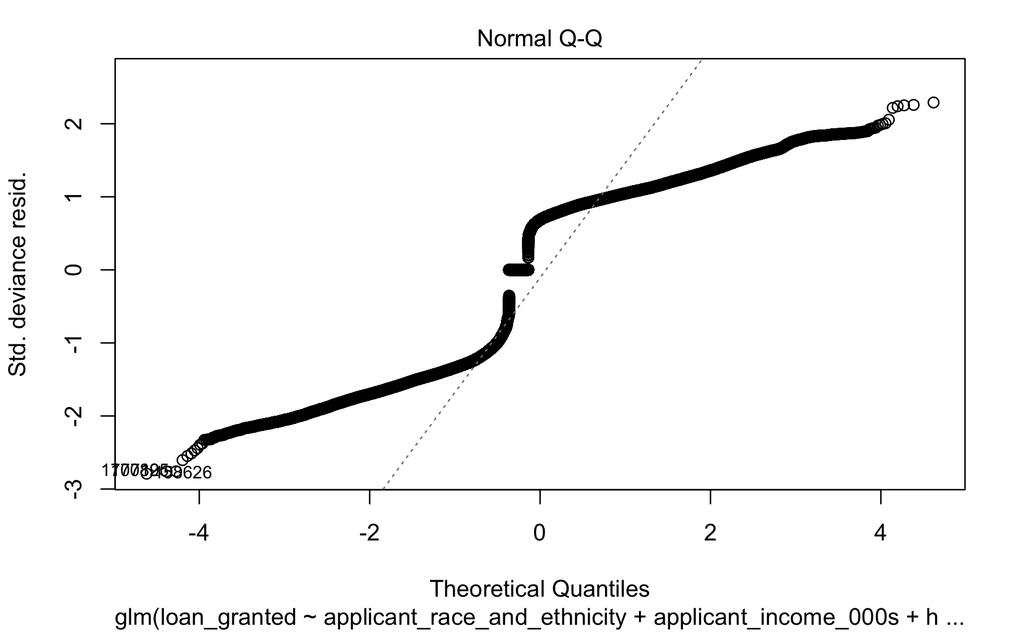

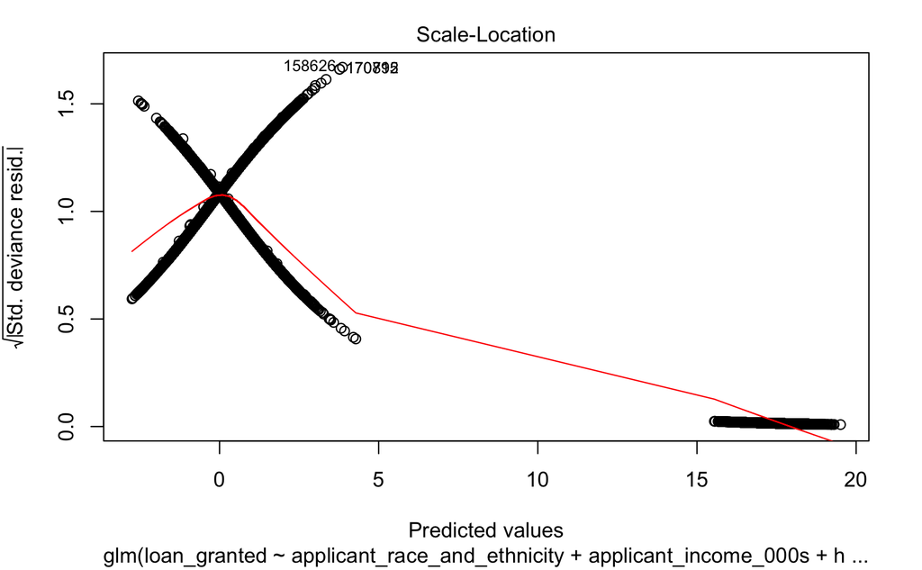

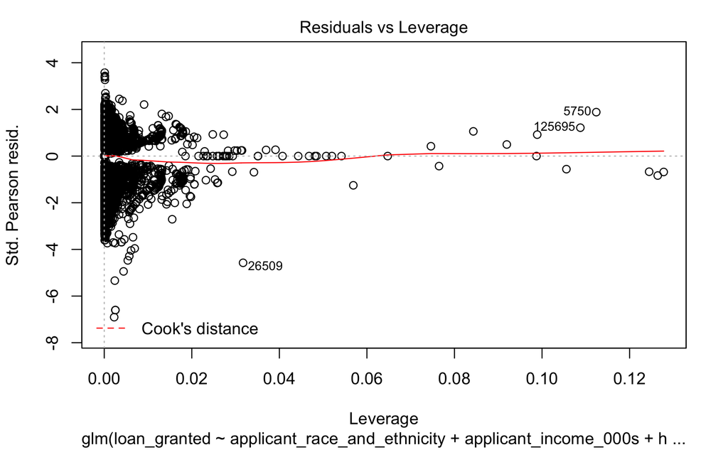

# Model with log of loan amount and income.

```r
summary(model_log_income_and_amount)
```

```
Call:
glm(formula = loan_granted ~ applicant_race_and_ethnicity + log_applicant_income_000s +
    hoepa_status + lien_status + owner_occupancy + preapproval +
    property_type + log_loan_amount_000s + msamd + applicant_sex +
    county_code + hud_median_family_income + tract_to_msamd_income +
    co_applicant_present + agency_code + minority_population,
    family = binomial(link = "logit"), data = train)

Deviance Residuals:
    Min       1Q   Median       3Q      Max
-2.3951  -1.1553   0.6746   0.9474   2.4014

Coefficients:
                                                                                                                Estimate
(Intercept)                                                                                                    2.266e+01
applicant_race_and_ethnicityAsian                                                                              6.699e-01
applicant_race_and_ethnicityBlack or African American                                                          2.342e-01
applicant_race_and_ethnicityHispanic or Latino                                                                 3.432e-01
applicant_race_and_ethnicityInformation not provided by applicant in mail, Internet, or telephone application  2.706e-01
applicant_race_and_ethnicityNative Hawaiian or Other Pacific Islander                                          3.814e-01
applicant_race_and_ethnicityNot applicable                                                                    -5.356e-02
applicant_race_and_ethnicityWhite                                                                              7.732e-01
log_applicant_income_000s                                                                                      2.903e-01
hoepa_status2                                                                                                 -1.711e+01
lien_status2                                                                                                  -3.172e-01
lien_status3                                                                                                  -5.267e-01
lien_status4                                                                                                   1.674e+01
owner_occupancy2                                                                                              -1.296e-01
owner_occupancy3                                                                                              -5.915e-02
preapproval2                                                                                                  -6.103e-02
preapproval3                                                                                                  -8.593e-01
property_type2                                                                                                -9.400e-01
property_type3                                                                                                -3.340e-01
log_loan_amount_000s                                                                                          -4.672e-02
msamd                                                                                                         -8.588e-05
applicant_sex2                                                                                                -1.519e-02
applicant_sex3                                                                                                 3.038e-02
applicant_sex4                                                                                                 1.630e+00
county_code3                                                                                                   1.611e+00
county_code5                                                                                                   1.374e+00
```

[output cut: 469 more lines]

```
agency_code5                                                                                                  **
agency_code7                                                                                                  ***
agency_code9                                                                                                  ***
minority_population                                                                                           ***
---
Signif. codes:  0 ‘***’ 0.001 ‘**’ 0.01 ‘*’ 0.05 ‘.’ 0.1 ‘ ’ 1

(Dispersion parameter for binomial family taken to be 1)

    Null deviance: 336299  on 257896  degrees of freedom
Residual deviance: 294172  on 257798  degrees of freedom
  (332 observations deleted due to missingness)
AIC: 294370

Number of Fisher Scoring iterations: 16
```

# Model 2 with loan to income ratio.

```r
model_loan_income_ratio <- glm(loan_granted~applicant_race_and_ethnicity+applicant_income_000s+loan_to_income_ratio+co_applicant_present+co_applicant_sex+hoepa_status+lien_status+owner_occupancy+preapproval+property_type+loan_amount_000s+msamd+applicant_sex+county_code+hud_median_family_income+tract_to_msamd_income+agency_code+minority_population, family = binomial(link='logit'), data=train)
```

```
glm.fit: fitted probabilities numerically 0 or 1 occurred
```

# Model plots

```r
plot(model_loan_income_ratio)
```

[output not shown]

# Model 2 with log of loan amounts and income and loan to income ratio.

# Prediction based on the base model.

# Compute statistics like classification errror, confusion matrix, etc based

# on our predictions.

## Function to calculate precision and recall using confusion matrix

# Model performance.

```r
performance <- prediction_stats(fitted.probs, test)
```

```
[1] "Accuracy 0.68071132040399"
Confusion Matrix and Statistics

          Reference
Prediction FALSE  TRUE
     FALSE  7132  4628
     TRUE  15984 36812

               Accuracy : 0.6807
                 95% CI : (0.6771, 0.6843)
    No Information Rate : 0.6419
    P-Value [Acc > NIR] : < 2.2e-16

                  Kappa : 0.2208

 Mcnemar's Test P-Value : < 2.2e-16

            Sensitivity : 0.8883
            Specificity : 0.3085
         Pos Pred Value : 0.6972
         Neg Pred Value : 0.6065
             Prevalence : 0.6419
         Detection Rate : 0.5702
   Detection Prevalence : 0.8178
      Balanced Accuracy : 0.5984

       'Positive' Class : TRUE
```

## Precision and Recall

```r
precision_recall(performance$table)
```

```
[1] "Precision"
[1] 0.6972498
[1] "Recall"
[1] 0.8883205
```

# Plot TPR vs FPR

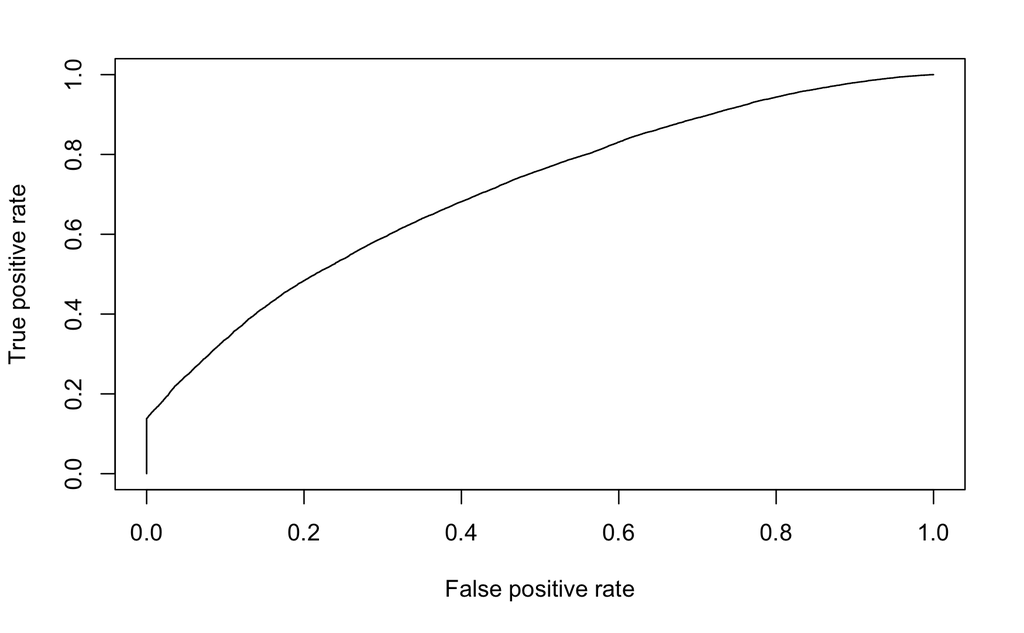

# Prediction based on the model with loan to income ratio

# Model performance.

```r
performance
```

```
Confusion Matrix and Statistics

          Reference
Prediction FALSE  TRUE
     FALSE  7127  4433
     TRUE  15989 37007

               Accuracy : 0.6837
                 95% CI : (0.6801, 0.6872)
    No Information Rate : 0.6419
    P-Value [Acc > NIR] : < 2.2e-16

                  Kappa : 0.2264

 Mcnemar's Test P-Value : < 2.2e-16

            Sensitivity : 0.8930
            Specificity : 0.3083
         Pos Pred Value : 0.6983
         Neg Pred Value : 0.6165
             Prevalence : 0.6419
         Detection Rate : 0.5733
   Detection Prevalence : 0.8209
      Balanced Accuracy : 0.6007

       'Positive' Class : TRUE
```

## Precision and Recall

```r
precision_recall(performance$table)
```

```
[1] "Precision"
[1] 0.698298
[1] "Recall"
[1] 0.8930261
```

# Prediction based on the model with log income and loan to income ratio

# Model performance.

```r
performance<-prediction_stats(fitted_2_log_income.probs, test)
```

```
[1] "Accuracy 0.687991821054588"
Confusion Matrix and Statistics

          Reference
Prediction FALSE  TRUE
     FALSE  7538  4564
     TRUE  15578 36876

               Accuracy : 0.688
                 95% CI : (0.6844, 0.6916)
    No Information Rate : 0.6419
    P-Value [Acc > NIR] : < 2.2e-16

                  Kappa : 0.2414

 Mcnemar's Test P-Value : < 2.2e-16

            Sensitivity : 0.8899
            Specificity : 0.3261
         Pos Pred Value : 0.7030
         Neg Pred Value : 0.6229
             Prevalence : 0.6419
         Detection Rate : 0.5712
   Detection Prevalence : 0.8125
      Balanced Accuracy : 0.6080

       'Positive' Class : TRUE
```

```r
precision_recall(performance$table)
```

```
[1] "Precision"
[1] 0.703016
[1] "Recall"
[1] 0.8898649
```